# HW13_MQari

Mubashira Qari

2024-04-28

### Question 1:

Use integration by substitution to solve the integral below.

$$\int4e^{-7x} \ dx$$

### Solution:

We will denote u with -7x to apply the integration by substitution.

$$u = -7x$$

Solving for dx

$$\frac{du}{dx}=-7$$

$$dx = \frac{du}{-7}$$

Now, we substitute u and dx into the integral:

$$\int4e^{-7x} \ dx =
\int4e^{u}*\frac{du}{-7}$$

$$\int4e^{-7x} \ dx = \frac {-4}{7}\int
e^{u}*{du}$$

$$\int4e^{-7x} \ dx = \frac
{-4}{7}e^{u}+C$$

$$\int4e^{-7x} \ dx = \frac
{-4}{7}e^{-7x}+C$$

where C is the constant of integration

### Question 2:

Biologists are treating a pond contaminated with bacteria. The level of contamination is changing at a rate of

$$\frac{dN}{dt}={3150}{t^4}
-220$$

bacteria per cubic centimeter per day, where t is the number of days since treatment began. Find a function N( t ) to estimate the level of contamination if the level after 1 day was 6530 bacteria per cubic centimeter.

### Solution:

We will integrate the given rate of change of contamination with respect to time t to find find the function N(t) that estimates the level of contamination.

$$\frac{dN}{dt}={3150}{t^4}
-220$$

First find N(t), where
$$N(1)=6530$$

Next, integrate the given rate function.

$$\frac{dN}{dt}={3150}{t^4}
-220$$

$$\int(-3150{t^4-220)} \ dt$$

$$\frac{-3150}{5}t^5-220t+C$$

Now substitute the initial condition N(1)=6530 to find constant C:

$$N(1) =
\frac{-3150}{5}(1)^5-220(1)+C=6530$$

$$\frac{-3150}{5}-220+C=6530$$

$$\frac{-3150}{5}-220+C=6530$$

$$-630-220+C=6530$$

$$-850+C=6530$$

$$C=6530+850$$

$$C=7380$$

Now function N(t) which estimates the level of contamination at any given time t is the number of days since treatment began.

$$N(t) =
\frac{-3150}{5}(t)^5-220(t)+7380$$

### Question 3:

$$f(x) = 2x-9$$

### Solution:

```r
func_3 <- function(x)
{
  2 * x - 9
}
integrate(func_3, lower = 4.5, upper = 8.5)
```

```
## 16 with absolute error < 1.8e-13
```

### Question 4:

Find the area of the region bounded by the graphs of the given equations:

$$y=x^2-2x-2, y=x+2$$

### Solution:

First find the points of intersection between the two curves to determine the limits of integration.

$$x^2-2x-2 = x+2$$

$$x^2-3x - 4 = 0$$

Find the factors of quadratic equations

$$(x-4)(x+1)=0$$

Solutions are:

$$x=4$$

$$x=-1$$

Now integrate the difference of the upper and lower curve

$$y=x +2$$

$$y=x^2 +2x-2$$

$$A = \int_{-1}^{4}[(x+2)-(x^2-2x-2)]dx$$

$$A = \int_{-1}^{4}(x+2-x^2+2x+2)dx$$

$$A = \int_{-1}^{4}(x^2+3x+4)dx$$

$$A = [\frac{-x^3}{3} +
\frac{3x^2}{2}+4x]_{-1}^{4}$$

Now replace the upper and lower limit

$$A = [\frac{-4^3}{3} +
\frac{3(4)^2}{2}+4(4)]-[\frac{-(-1)^3}{3} + \frac{3(-1)^2}{2}+4(-1)]$$

$$A = [\frac{-64}{3} +
24+16]-[\frac{1}{3} + 1.5-4]$$

$$A = [\frac{-64}{3} +
24+16]+[\frac{-1}{3} - 1.5+4]$$

$$A = [\frac{-64}{3} + 40-\frac{1}{3} -
1.5+4]$$

$$A = [\frac{-65}{3} + 42.5]$$

$$A = -21.6667+42.5$$

$$A = -21.6667+42.5$$

$$A = 20.8333$$

The area between the curves from x=−1 to x=4 is 20.8333 square units. We confirm using pracma R module.

```r
library(pracma)
# Define the  function
integrand <- function(x) { (x + 2) - (x^2 - 2*x - 2) }

# Calculate the integral from x = -1 to x = 4
area <- integral(integrand, -1, 4)
area
```

```
## [1] 20.83333
```

Let us plot two functions. f1(x) is in red and f2(x) is in green.

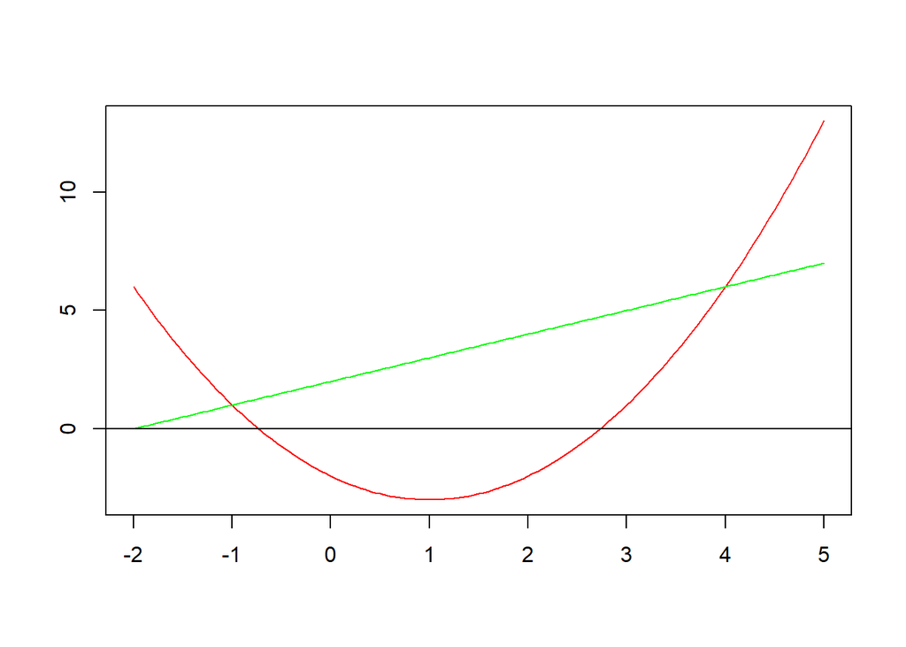

```r
eq1 <- function(x) x^2-2*x-2
eq2 <- function(x) x+2

min <- -2
max <- 5
x1 <- seq(min, max, 0.05)
plot(x1, eq1(x1), type='l', col="red",
     xlab="", ylab="")
lines(x1, eq2(x1), col="green")
abline(h=0)
```

Finding roots of the quadratic function f1(x)

```r
roots <- polyroot(c(-2, -2, 1))
```

Finding the intersection of two functions.

They intersect where f1(x)−f2(x)=0

$$(x^2 -2x-2)-(x+2)=0x^2-3x-4=0$$

Finding the roots

```r
intersection <- polyroot(c(-4, -3, 1))

Xs <- c(intersection[1], roots, intersection[2])
Xs
```

```
## [1] -1.0000000+0i -0.7320508+0i  2.7320508+0i  4.0000000+0i
```

```r
Xs <- c(intersection[1], roots, intersection[2])
Xs
```

```
## [1] -1.0000000+0i -0.7320508+0i  2.7320508+0i  4.0000000+0i
```

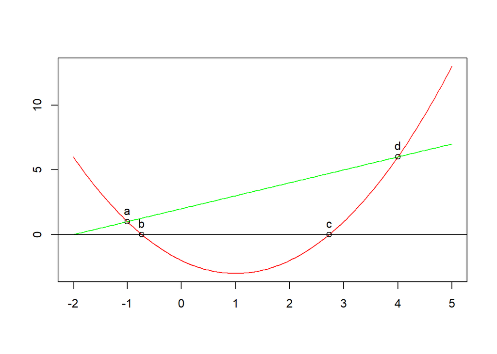

```r
plot(x1, eq1(x1), type='l', col="red",
     xlab="", ylab="")
lines(x1, eq2(x1), col="green")
points(Xs, eq1(Xs))
text(Xs, eq1(Xs), labels = c("a","b","c","d"), pos = 3)
abline(h=0)
```

```r
# Find individual parts
a1 <- integrate(eq2, lower=Xs[1], upper=Xs[4])
a2 <- integrate(eq1, lower=Xs[1], upper=Xs[2])
a3 <- integrate(eq1, lower=Xs[3], upper=Xs[4])
a4 <- integrate(eq1, lower=Xs[2], upper=Xs[3])
# Combining all we will find the following
area <- a1$value-a2$value-a3$value-a4$value
area
```

```
## [1] 20.83333
```

### Question 5:

A beauty supply store expects to sell 110 flat irons during the next year. It costs $3.75 to store one flat iron for one year.There is a fixed cost of $8.25 for each order. Find the lot size and the number of orders per year that will minimize inventory costs.

### Solution:

Number of orders (x) * Lot Size (n) = 110

C = costs

$$C = 8.25x + 3.75 *\frac {110/x}{2}$$

$$C = 8.25x + 3.75 *\frac {55}{x}$$

$$C = 8.25x + \frac {206.25}{x}$$

To minimize costs, set derivative = zero

$$C' = 8.25 - \frac {206.25}{x^2}$$

$$0 = 8.25 - \frac {206.25}{x^2}$$

$$\frac {206.25}{x^2}=8.25$$

$$206.25 = 8.25x^2$$

$$\frac {206.25}{8.25}= x^2$$

$$25= x^2$$

The number of orders per year that will minimize inventory costs is 5.

The lot size is 22 because 22 x 5 = 110

### Question 6:

Use integration by parts to solve the integral below.

$$A = \int(9x)* x^6dx$$

### Solution:

Apply the integration to solve the integral below:

$$A = \int(9x)* x^6dx$$

Applying the formula

$$fg' = fg - \int(f'g)$$

$$f = ln(9x)$$

$$f' = \frac{1}{x}$$

$$g' = x^6$$

$$g = \frac {x^7}{7}$$

Now substitute the formula

$$ln(9x)* x^6 =
ln(9x)*\frac{x^7}{7}-\int\frac{1}{x}*\frac{x^7}{7}$$

$$ln(9x)* x^6 =
ln(9x)*\frac{x^7}{7}-\int\frac{x^6}{7}$$

$$ln(9x)* x^6 = \frac
{ln(9x)*x^7}{7}-\frac{x^7}{49}$$

$$ln(9x)* x^6 = \frac
{7*ln(9x)*x^7}{49}-\frac{x^7}{49}$$

$$ln(9x)* x^6 = \frac
{x^7(7*ln(9x))-1}{49}+c$$

### Question 7:

Determine whether f ( x ) is a probability density function on the interval [1, e^6]. If not, determine the value of the definite integral.

$$f(x)=\frac{1}{6x}$$

### Solution:

$$\int\frac{1}{6x}dx$$

$$\int_{1}^{e^6}\frac{1}{6x}dx$$

$$\frac{1}{6}\int_{1}^{e^6}\frac{1}{x}dx$$

$$\frac{1}{6}(ln(x)|_{1}^{e^5}$$

$$(\frac{1}{6})(ln(e^6))-(\frac{1}{6})(ln(1))$$

Now since ln(1)=0, we are left with the following:

$$(\frac{1}{6})(ln(e^6))$$

$$=ln(e^6)=1$$

$$f(x)=\frac{1}{6x}$$

This is the probability density function on the interval[1,e^6]